# ExtraaLearn Project

## **Random Forest Classifier**

### Building Random Forest Model

```python
# Fitting the random forest tree classifier on the training data
rf_estimator = RandomForestClassifier(random_state=42)
rf_estimator.fit(X_train, y_train)
```

```
RandomForestClassifier(random_state=42)
```

#### Checking the Random Forset model performance on training set

```
              precision    recall  f1-score   support

           0       1.00      1.00      1.00      2273
           1       1.00      1.00      1.00       955

    accuracy                           1.00      3228
   macro avg       1.00      1.00      1.00      3228
weighted avg       1.00      1.00      1.00      3228
```

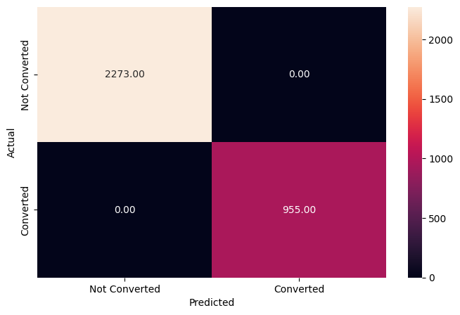

```python
# Checking performance on the training data
y_pred_train3 = rf_estimator.predict(X_train)
metrics_score(y_train, y_pred_train3)
```

**Observations:**

#### Checking the Random Forset model performance on testing set

```
              precision    recall  f1-score   support

           0       0.87      0.92      0.90       962
           1       0.80      0.69      0.74       422

    accuracy                           0.85      1384
   macro avg       0.83      0.81      0.82      1384
weighted avg       0.85      0.85      0.85      1384
```

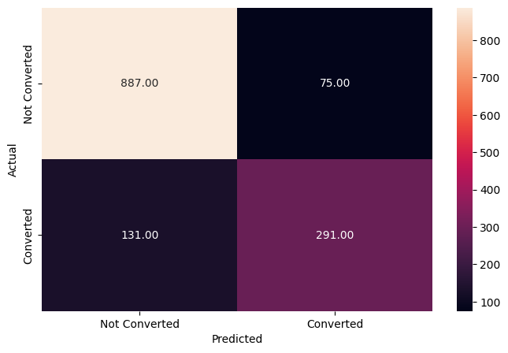

```python
# Checking performance on the testing data
y_pred_test3 = rf_estimator.predict(X_test)
metrics_score(y_test, y_pred_test3)
```

**Observations:**

##### 1. Overall Performance:

- 85% accuracy - strong overall performance
- Balanced metrics across precision and recall

##### 2. Predicting Non-Converters (Class 0):

- 92% recall - excellent at identifying non-converting leads
- 87% precision - high reliability when predicting someone won't convert Only 75 false positives - minimal wasted resources

##### 3. Predicting Converters (Class 1):

- 69% recall - identifies about 7 out of 10 actual converters
- 80% precision - when it predicts conversion, it's right 80% of the time
- 131 false negatives - missing some potential conversion opportunities

##### 4. Business Impact:

- Strong at avoiding false positives (predicting conversion when it won't happen)
- Moderate at capturing all potential converters
- Good balance between precision and recall for business decision-making

##### 5. Confusion Matrix Highlights:

- 887 true negatives - correctly identified non-converters
- 291 true positives - correctly identified converters
- Overall shows good classification performance across both classes

This untuned Random Forest performs well out-of-the-box, with particularly strong performance on identifying non-converters while maintaining good precision for the conversion class.

### **Random Forest Classifier - Hyperparameter Tuning**

The following parameters are used to tune the decision tree:

- n_estimators: Find the optimal number of trees can help balance performance and efficiency
- max_depth: Helps control the complexity of the model, making it more generalizable to unseen data.
- min_samples_leaf: Reduces overfitting by ensuring that leaves have a minimum number of observations
- max_features: Helps to reduce overfitting and allows the model to generalize better by using a subset of features
- max_samples: Encourages diversity among the trees, which can lead to better model performance.
- class_weight: Useful for handling imbalanced datasets, ensuring that the model pays appropriate attention to all classes, especially the minority class

```python
# Choose the type of classifier
rf_estimator_tuned = RandomForestClassifier(criterion = "entropy", random_state = 7)

# Grid of parameters to choose from
parameters = {"n_estimators": [110, 120],
    "max_depth": [6, 7],
    "min_samples_leaf": [20, 25],
    "max_features": [0.8, 0.9],
    "max_samples": [0.9, 1],
    "class_weight": ["balanced",{0: 0.3, 1: 0.7}]
             }

# Type of scoring used to compare parameter combinations - recall score for class 1
scorer = metrics.make_scorer(recall_score, pos_label = 1)

# Run the grid search on the training data using scorer=scorer and cv=5
grid_obj = GridSearchCV(estimator=rf_estimator_tuned, param_grid=parameters, scoring=scorer, cv=5)

# Fit the grid search to the data
grid_obj.fit(X_train, y_train)

# Save the best estimator
rf_estimator_tuned = grid_obj.best_estimator_
```

```python
# Fitting the best algorithm to the training data
rf_estimator_tuned.fit(X_train, y_train)
```

```
RandomForestClassifier(class_weight='balanced', criterion='entropy',
                       max_depth=6, max_features=0.8, max_samples=0.9,
                       min_samples_leaf=25, n_estimators=120, random_state=7)
```

#### Checking the Optimized Random Forset model performance on training set

```
              precision    recall  f1-score   support

           0       0.94      0.83      0.88      2273
           1       0.68      0.87      0.76       955

    accuracy                           0.84      3228
   macro avg       0.81      0.85      0.82      3228
weighted avg       0.86      0.84      0.84      3228
```

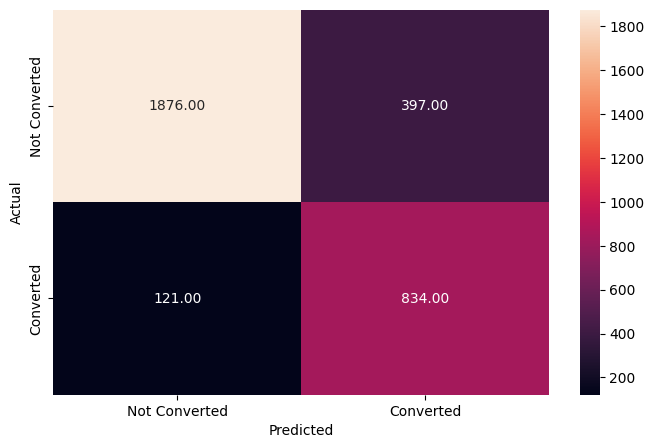

```python
# Checking performance on the training data
y_pred_train4 = rf_estimator_tuned.predict(X_train)
metrics_score(y_train, y_pred_train4)
```

#### Checking the Optimized Random Forset model performance on testing set

```
              precision    recall  f1-score   support

           0       0.93      0.83      0.87       962
           1       0.68      0.85      0.76       422

    accuracy                           0.83      1384
   macro avg       0.81      0.84      0.82      1384
weighted avg       0.85      0.83      0.84      1384
```

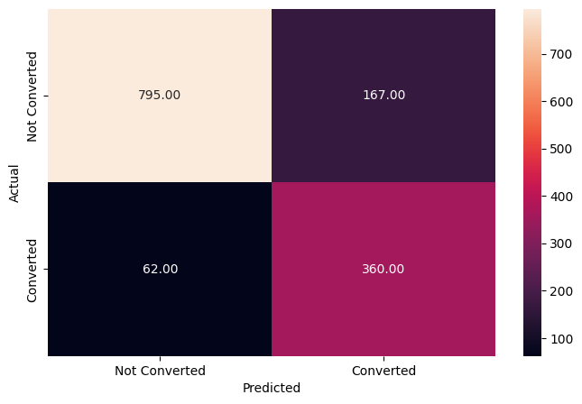

```python
# Checking performance on the test data
y_pred_train4 = rf_estimator_tuned.predict(X_test)
metrics_score(y_test, y_pred_train4)
```

**Observations:**

Comparing the optimized Random Forest with the untuned version, here are the key observations:

##### 1. Overall Performance Improvements

- Accuracy: Changed from 85% to 83% (slight decrease)
- Weighted Average F1-Score: Changed from 0.85 to 0.84 (slight decrease)

##### 2. Class 0 (Not Converted) Performance

- Precision: Improved from 0.87 to 0.93 (+6%)
- Recall: Decreased from 0.92 to 0.83 (-9%)
- True Negatives: Decreased from 887 to 795 cases

##### 3. Class 1 (Converted) Performance

- Precision: Decreased from 0.80 to 0.68 (-12%)
- Recall: Significantly improved from 0.69 to 0.85 (+16%)
- True Positives: Increased from 291 to 360 cases (+69 more conversions identified)

##### 4. Error Distribution Changes

- False Negatives: Decreased from 131 to 62 (-69 cases)
- False Positives: Increased from 75 to 167 (+92 cases)

##### 5. Business Impact Analysis

- Better at Finding Conversions: The optimized model identifies 16% more actual conversions (higher recall for class 1)
- More False Alarms: The model now incorrectly flags more non-converters as converters
- Trade-off Shift: Clear shift from precision to recall for the conversion class

##### 6. Strategic Implications

- The optimized model is better suited for applications where:
- Finding all potential converters is more important than precision
- Missing conversion opportunities is considered more costly than pursuing false leads
- Marketing resources are available to handle more potential leads, even if some won't convert

The optimization has effectively shifted the model's focus toward identifying more potential conversions at the cost of some precision, which may align better with business goals of maximizing conversion opportunities.

#### Feature Importance of the model

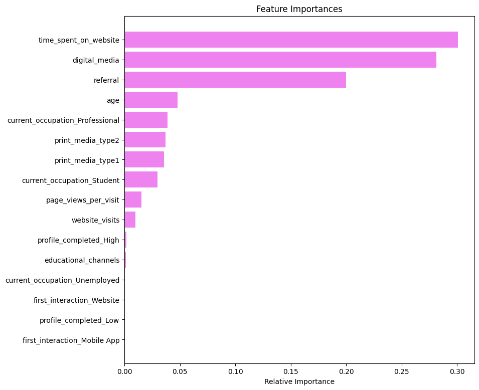

```python
importances = rf_estimator_tuned.feature_importances_
indices = np.argsort(importances)
feature_names = list(X.columns)
plt.figure(figsize = (9, 9))
plt.title('Feature Importances')
plt.barh(range(len(indices)), importances[indices], color = 'violet', align = 'center')
plt.yticks(range(len(indices)), [feature_names[i] for i in indices])
plt.xlabel('Relative Importance')
plt.show()
```

**Observations:**

## **Is Pruning for this Random Forest mode needed?**

Pruning is already being applied through the hyperparameter tuning process:

- The max_depth parameter (6 to 7) limits how deep each tree can grow and so is a way form of pruning.
- The min_samples_leaf parameter (20 to 25) prevents splits that would create leaves with fewer samples than this threshold, effectively pruning potential branches.
- The max_features parameter (values 0.8 and 0.9) limits the number of features considered at each split, which indirectly controls tree complexity.
- The GridSearchCV finds the optimal parameters combination to balance model complexity and performance, which is essentially what pruning aims to achieve.

**Therefore, additional pruning is not need.**

#### Comparing the results between Decision Tree and Random Forest:

##### 1. Overall Performance:

- Random Forest shows better overall accuracy (83% vs 80%)
- Random Forest has better weighted average metrics across the board

##### 2. Class Balance:

- Decision Tree has slightly better recall for conversions (86% vs 85%)
- Random Forest has better precision for conversions (68% vs 62%)
- Random Forest has significantly better recall for non-conversions (83% vs 77%)

##### 3. Error Patterns:

- Decision Tree produces more false positives (224 vs 167)
- Random Forest has slightly more false negatives (62 vs 57)
- Random Forest shows more balanced error distribution

##### 4. Business Implications:

- Decision Tree identifies slightly more actual conversions (5 more)
- Random Forest has fewer false alarms (57 fewer)
- Random Forest correctly identifies more non-conversions (57 more)

#### Optimized Random Forest is the better choice because:

- Higher Overall Accuracy: 83% vs 80%
- Better Balanced Performance: More consistent across both classes
- Fewer False Positives: 167 vs 224, which means fewer wasted resources on non-converting leads
- Better Precision-Recall Balance: While the Decision Tree has slightly higher recall for conversions, the Random Forest's better precision means marketing efforts would be more efficiently targeted
- More Robust Predictions: Random Forests are generally less prone to overfitting than Decision Trees

## **Conclusion**

Based on all the analysis above, the following conclusions can be drawn.

## **Insights:**

### **Leads more likely to be converted to paid customers have following characteristics:**

##### Demographic

- Professionals dominate both in numbers and conversion rate, followed by unemployed and students.
- Both professional and unemployed group have similar age range (35-60) and average age (50), while students are around 18 to 22.

##### Engagement Patterns:

- Website visit of about 2.5 - 5 times (assume every week)
- 2-5 pages view per visit
- Total time spent on website over 2 times of not converted
- High or medium level of profile completed dominates in numbers and conversion rate
- Trend to have intense emails communication near decision making stage, and have frequent websit vists before make decisions. This indicates that leads decide to enroll for their courses on websites after emails communication.

##### Marketing Channel:

- All of the channels such as digital channel, print media channels, educational channel are not effective in leads conversion.
- Low referral rate indicate that ExtraaLean's popularity is not enough.
- Website and mobile app are the most important touch point as first user interaction.

### **Typical profile of a lead which is likely to be converted to a paid customer:**

- Employment status as professionals or unemployed
- Age around 42 to 58
- Have high or medium profile completed
- Have about 2-5 website visits
- Have 2-5 page view per website visit
- Have email activities as the last activity

## **Business Recommendations:**

### User Group marketing:

- Develop programs that can help professional to advance their career paths.
- Provide information about how the programs are related to career advancement.
- Implement occupation-specific marketing campaigns to attract unemployed leads.
- Provde discount packages or entry-level programs for students.

### User Experience:

- Improve website navigation to attract 5+ page views.
- Improve personalized user journeys, for examples:
  - automatic recommendations of programs specific to leads profiles
  - auto email notice of new programs related to leads profiles
  - visualized learning paths for specific certifications and related programs
- As some leads decide not to join any course even they have many website visits. ExtraaLearn's website layout should provide better and efficient online users experiences such as
  - quick search by key words
  - system can go back to previous page when users visit again
  - clear display of important information such as course fee, course duration, certifications, etc

### User Engagement:

- Strength website content to provide course information of hot subjects (AI, machine learning, etc), online chat bot to answer users queries, feedback from course graduates.
- Provide free trial of a small part of programs in order to promote more website visits.
- Keep close contact with leads by phone communication (text messaging should be used before phone call).
- Provide free-interest installment payments or discounts for unemployed leads or students.

### Marketing Approach:

- Review and investigate the low usage and conversion rates of digital media and education channel.
- Develop more useful content for digital media and education channel.
- Provide course fee discount to attract referral opportunities.
- Cooperate with internationally famous colleges to provide hit programs, or launch promotion campaigns and career fairs. This strategy can enhance ExtraaLearn's popularity.

### Course Content:

- Develop career related programs for leads (assume profession data will be collected).
- Provide diversified range of programs to attract professionals from different sectors.
- Develop courses of different durations to satisfy different needs.

### Technical Improvements:

- Invest more in IT resources to maintain consistent performance of website and mobile app because they are both critical users interaction points.
- Website or mobile app response speed should be optimized to order to attract more visits or page views.